# Week 13 Practice: Python Data Visualization

In-class file

Author

SOLUTIONS

**How to use this file.** Keep it open in Positron during tonight’s Zoom class.

- **Demo** sections: type along with me.
- **Your turn**: work on it when I say go. **Core** is for everyone; **Stretch** and **Experienced** are extras.

**Seeing your results.** Python only shows the result of the **last line** in a cell, and plots follow the same rule:

- A plotnine plot shows up when it’s the **last** thing in the cell. If you want two plots, use two cells.
- **While you work:** put your cursor on the first line of a plot (the `(`) and press **Cmd/Ctrl + Enter**. Positron sends the whole plot and it appears in the **Plots** pane. If nothing appears, save the plot to a name and run `p.show()`.
- **matplotlib/seaborn:** the figure shows up at the end of the cell. A semicolon `;` at the end of the last line hides a stray text label like `Text(0.5, 1.0, '...')`.

**New packages this week.** If `from plotnine import *` gives `ModuleNotFoundError`, run this in the Positron **Python console** (not this document), then restart the session (↻):

```python
%pip install plotnine seaborn
```

**Data:** `penguins.csv`, `volleyball_ncaa_div1_2022_23_clean.csv`, and `ucbadmit.csv` in the `data` folder inside your `STAT_7500` folder.

```python
import numpy as np
import pandas as pd
import matplotlib.pyplot as plt
import seaborn as sns
import plotnine
from plotnine import *
from mizani.labels import label_percent

penguins = pd.read_csv("data/penguins.csv")
volleyball = pd.read_csv("data/volleyball_ncaa_div1_2022_23_clean.csv")
ucbadmit = pd.read_csv("data/ucbadmit.csv")

print(penguins.shape, volleyball.shape, ucbadmit.shape)
print("pandas  ", pd.__version__)
print("plotnine", plotnine.__version__)
print("seaborn ", sns.__version__)
```

```
(344, 8) (334, 15) (4526, 3)
pandas   3.0.5
plotnine 0.15.7
seaborn  0.13.2
```

# Demo 1: plotnine, layer by layer

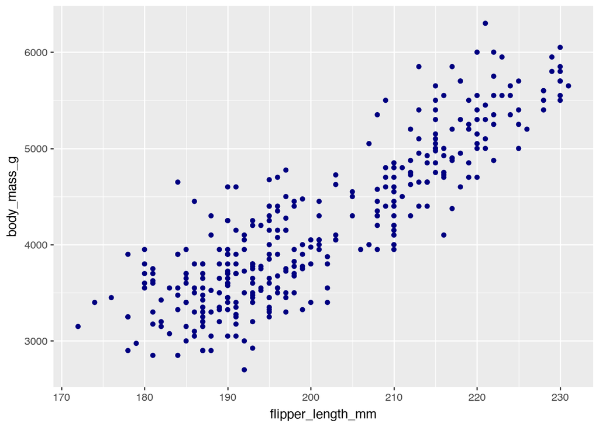

```python
# your code here
(
  ggplot(volleyball, aes(x="kills_per_set"))
    + geom_histogram(color="white", binwidth=0.5)
    + facet_wrap("region")
)

(
    ggplot(penguins, aes(x="bill_depth_mm", y="bill_length_mm", color="species"))
    + geom_point()
    + labs(title="Bill depth and length",
           x="Bill depth (mm)", y="Bill length (mm)", color="Species")
    + scale_color_cmap_d("viridis")
    + theme_minimal()
)

(
    ggplot(penguins, aes(x="flipper_length_mm", y="body_mass_g"))
    + geom_point(color="navy")
)

(
    ggplot(penguins, aes(x="flipper_length_mm", y="body_mass_g"))
    + geom_point(color="navy")
)
```

# Demo 2: bar charts

For percent labels on an axis, use `scale_y_continuous(labels=label_percent())`.

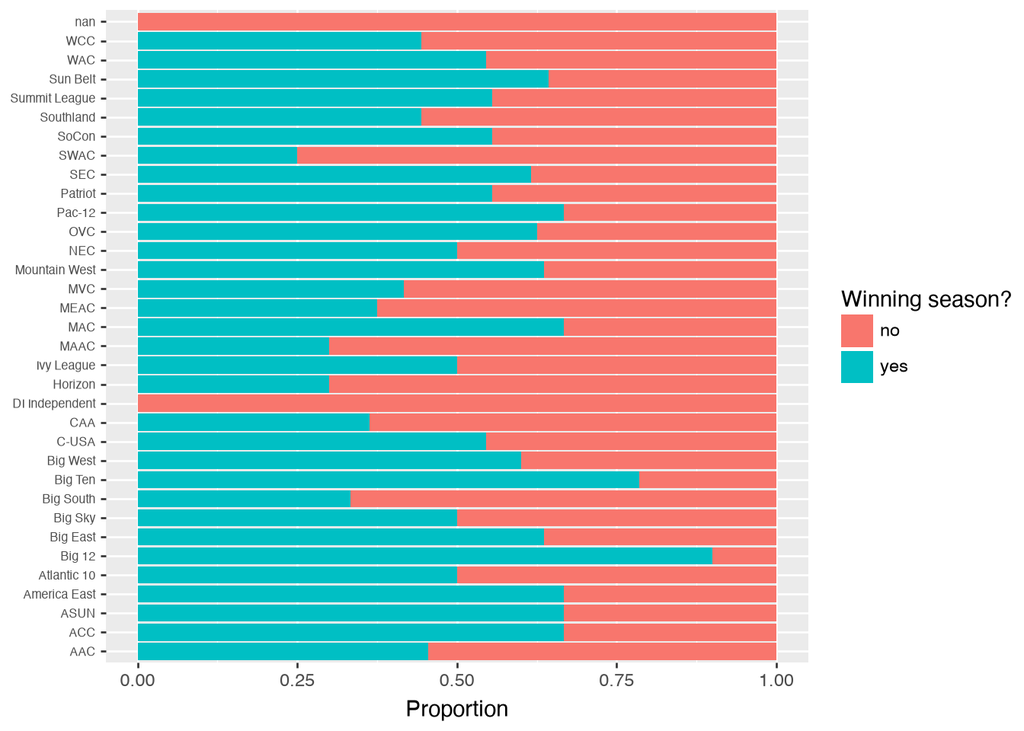

```python
# your code here
(
    ggplot(volleyball, aes(x="conference", fill="winning_season"))
    + geom_bar(position="fill")
    + coord_flip()
    + theme(axis_text_y=element_text(size=6))
    + labs(y="Proportion", x="", fill="Winning season?")
)
```

# Demo 3: ordering categories

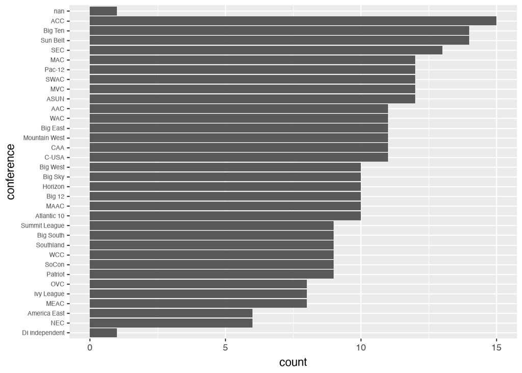

```python
# your code here
conf_order = volleyball["conference"].value_counts().index   # most common first

(
    volleyball
    .assign(conference=lambda d: pd.Categorical(d["conference"],
                                                categories=conf_order[::-1]))
    .pipe(ggplot, aes(x="conference"))
    + geom_bar()
    + coord_flip()
    + theme(axis_text_y=element_text(size=6))
)

conf_order = volleyball["conference"].value_counts(ascending=True).index   # most common first

(
    volleyball
    .assign(conference=lambda d: pd.Categorical(d["conference"],
                                                categories=conf_order))
    .pipe(ggplot, aes(x="conference"))
    + geom_bar()
    + coord_flip()
    + theme(axis_text_y=element_text(size=6))
)
```

# Demo 4: matplotlib, the Figure/Axes model

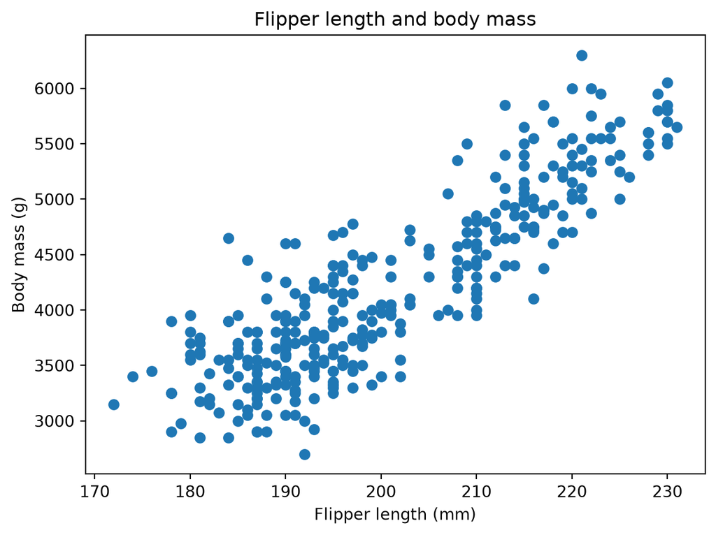

```python
# your code here
fig, ax = plt.subplots()          # a Figure (canvas) with one Axes (panel)
ax.scatter(penguins["flipper_length_mm"], penguins["body_mass_g"])
ax.set_title("Flipper length and body mass")
ax.set_xlabel("Flipper length (mm)")
ax.set_ylabel("Body mass (g)");
```

# Demo 5: seaborn and matplotlib together

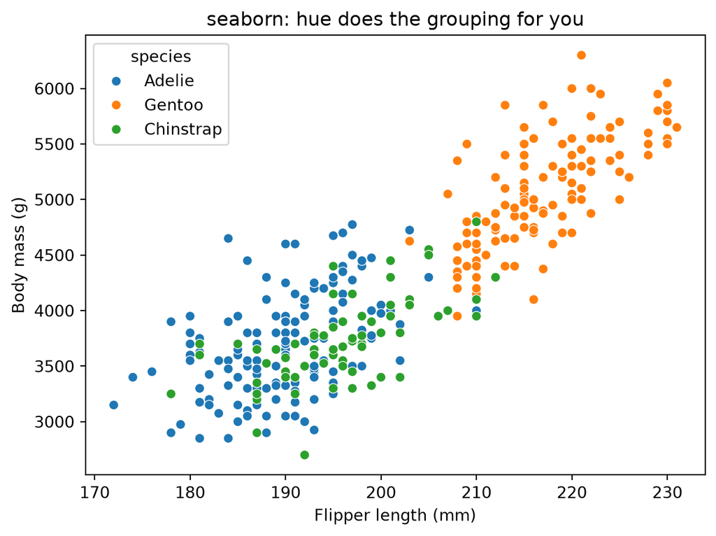

```python
# your code here
import seaborn as sns

fig, ax = plt.subplots()
sns.scatterplot(data=penguins, x="flipper_length_mm", y="body_mass_g",
                hue="species", ax=ax)
ax.set(title="seaborn: hue does the grouping for you",
       xlabel="Flipper length (mm)", ylabel="Body mass (g)");
```

# Your turn: recreate an R plot

This is the Week 5 plot of the Berkeley admissions data. Remember Simpson’s paradox: overall, men were admitted at a higher rate; within most departments, women were.

**Core.** Translate this plot into plotnine.

```r
ggplot(ucbadmit, aes(y = gender, fill = admit)) +
  geom_bar(position = "fill") +
  facet_wrap(. ~ dept) +
  scale_fill_viridis_d() +
  labs(title = "Admissions by gender and department",
       x = NULL, y = NULL, fill = NULL) +
  theme(legend.position = "bottom")
```

**What you should see:** one panel for each department (A to F), each with a bar for Female and a bar for Male, filled by Admitted and Rejected.

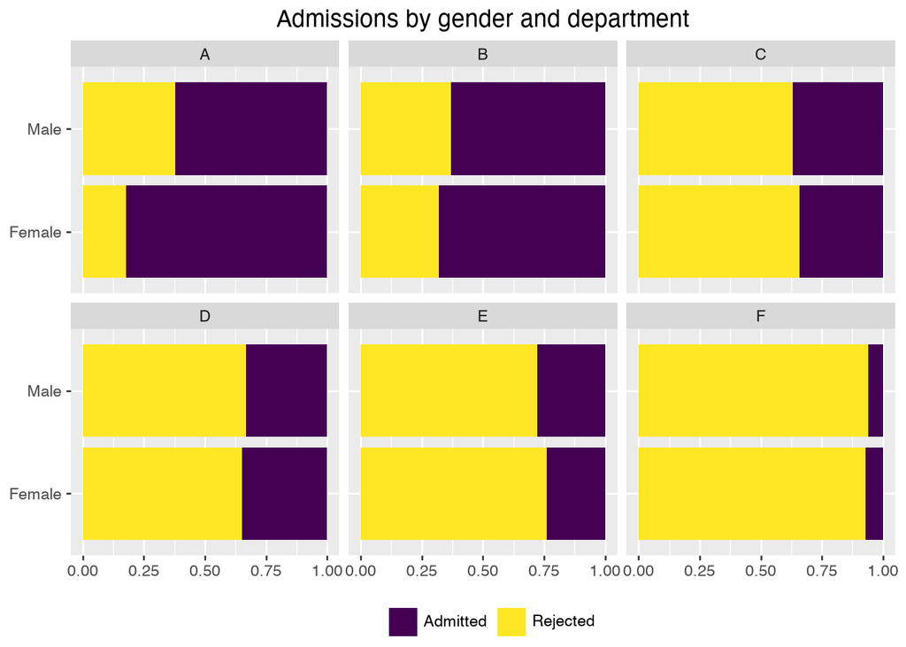

```python
(
  ggplot(ucbadmit, aes(x = "gender", fill = "admit")) +
  geom_bar(position = "fill") +
  coord_flip() +
  facet_wrap("dept") +
  scale_fill_cmap_d("viridis") +
  labs(title = "Admissions by gender and department",
       x = "", y = "", fill = "") +
  theme(legend_position = "bottom")
)
```

**Stretch.** Add percent labels, and order the departments by their **overall** admission rate (lowest to highest). *Hint:* compute the rate with `groupby("dept")`, sort it, and use its index as the `categories=` of a `pd.Categorical`.

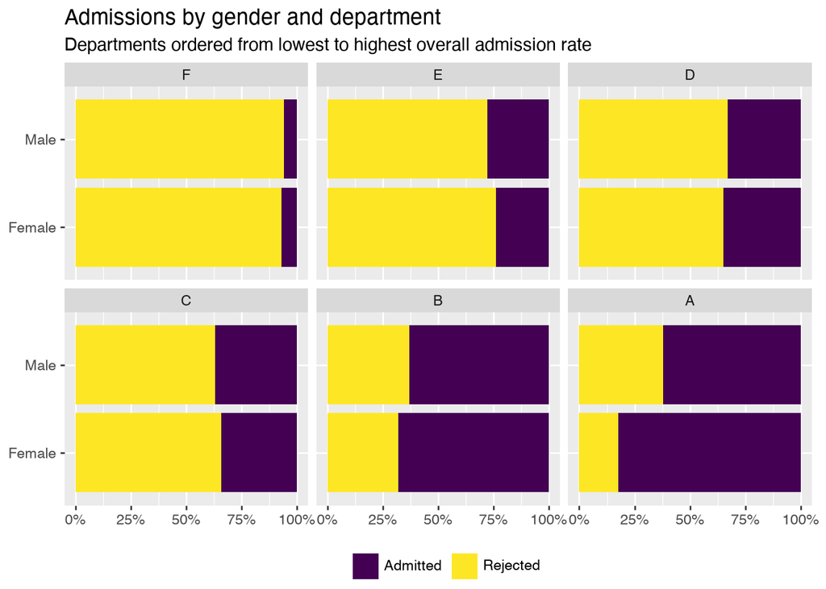

```python
dept_rates = (
    ucbadmit
    .assign(admitted=lambda d: d["admit"] == "Admitted")
    .groupby("dept")["admitted"]
    .mean()
    .sort_values()
)
dept_rates


(
    ucbadmit
    .assign(dept=lambda d: pd.Categorical(d["dept"], categories=dept_rates.index))
    .pipe(ggplot, aes(x="gender", fill="admit"))
    + geom_bar(position="fill")
    + coord_flip()
    + facet_wrap("dept")
    + scale_y_continuous(labels=label_percent())
    + scale_fill_cmap_d("viridis")
    + labs(title="Admissions by gender and department",
           subtitle="Departments ordered from lowest to highest overall admission rate",
           x="", y="", fill="")
    + theme(legend_position="bottom")
)
```

**Experienced.** Make an interactive version of your Demo 1 plot with **Altair** or **Plotly Express**, with a tooltip showing island and sex (`%pip install altair` or `%pip install plotly` first). How does its grammar compare with ggplot’s?

Fill in the `...` in one of these shells (columns are strings in both, like `aes()`). Run it in the console, not in this file.

```python
# Plotly Express: one function per plot type
import plotly.express as px
px.scatter(penguins, x="bill_depth_mm", y="bill_length_mm", color="species",
           hover_data=["island", "sex"],
           labels={"bill_depth_mm": "Bill depth (mm)",
                   "bill_length_mm": "Bill length (mm)"})

# Altair: data, then a mark, then encodings
import altair as alt
(
    alt.Chart(penguins)
    .mark_point()
    .encode(x=alt.X("bill_depth_mm", scale=alt.Scale(zero=False), title="Bill depth (mm)"),
            y=alt.Y("bill_length_mm", scale=alt.Scale(zero=False), title="Bill length (mm)"),
            color="species",
            tooltip=["species", "island", "sex"])
    .interactive()
)
```

[interactive chart not shown]

*Hint:* Altair starts its axes at zero. If the points bunch up, look up `alt.Scale(zero=False)`.